# Laboratory11

# Introduction

The creation of analytical confidence intervals and their interpretation will become increasingly important as you move further into statistics.

We must be able to derive the basic intervals from sampling distributions of pivotal statistics. Other interval formulae we will look up in appropriate text books and apply them to our various and particular problems.

# Calculation

There will be essentially two ways in which we will calculate intervals in R. The first way I will loosely call `using R as a calculator` and the second `using built in specialist functions`.

## Example 1

This technique will help you in making your own functions to carry out the task.

### Using R as a calculator

For the case of two independent samples (assumed equal population variances) we can estimate the difference in two population means by using the following formulae

$$S_p^2 = \frac{(n_1-1)s_1^2 + (n_2-1)s_2^2}{n_1+n_2-2}$$

$(1-\alpha)100$% ci for $\mu_1-\mu_2$ is

$$\bar{y}_1-\bar{y}_2 \pm t_{\alpha/2}S_p\left ( \frac{1}{n_1} + \frac{1}{n_2} \right )^{1/2}$$
where $t_{\alpha/2}=$`qt(1-alpha/2, n1+n2-2)`

Assume two samples `y1` and `y2`

```r
y1 <- rnorm(30,mean=35, sd =10)
y2 <- rnorm(40, mean=25, sd =10)

alpha <- 0.05

s1sq <- var(y1)
s2sq <- var(y2)
n1 <- length(y1)
n2 <- length(y2)

spsq <- ((n1-1)*s1sq + (n2-1)*s2sq)/(n1+n2-2)

mp <- c(-1,1) # make a vector to subtract and then add

t <- qt(1-alpha/2, n1+n2-2)

ci <- mean(y1)-mean(y2)+ mp*t*sqrt(spsq)*(1/n1 + 1/n2)^(1/2)
ci
ws#> [1]  5.002628 13.587158
```

### Using built in functions

We will use a side effect of `t.test()`

```r
t.test(y1,y2, var.equal = TRUE, conf.level = 0.95)$conf.int
ws#> [1]  5.002628 13.587158
ws#> attr(,"conf.level")
ws#> [1] 0.95
```

## Example 2

We can now look at the case when as before in Example 1 we have two samples but in this case **NOT** assume that the population variances are the same (use `var.test()` to test).

In such cases we use the `Welch` form of the two sample test and from it calculate the ci.

The formula for the degrees of freedom is quite different to that of Example 1.

$$\nu = \frac{(s_1^2/n_1 + s_2^2/n_2)^2}{\frac{(s_1^2/n_1)^2}{n_1-1} + \frac{(s_2^2/n_2)^2}{n_2-1}}$$

The $100(1-\alpha)$% ci for $\mu_1-\mu_2$ where population variances are not equal (assuming random sampling from each pop and the two samples are independent (same as in Example 1)) is given by:

$$\bar{Y}_1-\bar{Y}_2 \pm t_{\alpha/2}\sqrt{\frac{s_1^2}{n_1} + \frac{s_2^2}{n_2}}$$
where $t_{\alpha/2}=$`qt(1-alpha/2, nu)`

### Using R as a calculator

```r
nu = ((s1sq)/n1 +s2sq/n2)^2/((s1sq/n1)^2/(n1-1)+(s2sq/n2)^2/(n2-1))

tnu <- qt(1-alpha/2, nu)
ci <- mean(y1)-mean(y2) + mp*tnu*(s1sq/n1 + s2sq/n2)^(1/2)
ci
ws#> [1]  5.101483 13.488304
```

### Using built in functions

```r
t.test(y1,y2, var.equal = FALSE, conf.level = 0.95)$conf.int
ws#> [1]  5.101483 13.488304
ws#> attr(,"conf.level")
ws#> [1] 0.95
```

# More generally

There are a number of functions useful in making confidence intervals for different models. We will not get into many new models but it will be good for you to get the idea of how to calculate intervals and understand the difference in types of intervals.

> 1. Confidence Intervals
> 2. Prediction Intervals

## Regression

If the model is SLR

$$y_i=\beta_0 + \beta_1 x_i + \epsilon_i$$

$$\epsilon_i \sim N(0,\sigma^2)$$

The following code will make confidence intervals for $\beta_0$ and $\beta_1$.

In fact any linear model that is used to create objects through `lm()` can be used in `confint()` to construct ci’s

```r
ylm <- lm(LENGTH ~ WEIGHT, data = ddt)
stats::confint(ylm, c("(Intercept)", "WEIGHT"), level=0.95)
ws#>                    2.5 %      97.5 %
ws#> (Intercept) 27.698324621 32.80854109
ws#> WEIGHT       0.009672204  0.01425632
```

The same generic function `confint()` have methods for `glm` and `nls` as well.

We may want to find confidence intervals for `E(Y|x_p)` this can be done using the function `predict()`.

Supose `xp = c(1005,1020)` and we wish to find the confidence intervals for $E(LENGTH|WEIGHT=xp)$. That is, the confidence interval for the expected length when the weight takes the values `xp`

```r
predict(ylm, data.frame(WEIGHT = c(1005,1020)), interval = "confidence")
ws#>        fit      lwr      upr
ws#> 1 42.27751 41.41137 43.14366
ws#> 2 42.45698 41.59422 43.31973
```

We might ask for a `prediction` interval, that is $LENGTH|WEIGHT = x_p$. In this case we are interested in future responses at the given values of $WEIGHT$

```r
predict(ylm, data.frame(WEIGHT = c(1005,1020)), interval = "prediction")
ws#>        fit      lwr      upr
ws#> 1 42.27751 31.92048 52.63455
ws#> 2 42.45698 32.10022 52.81373
```

## Improvement of the model

As you perfect your knowledge and skills the final product can be quite impressive.

```r
ylm2 <- lm(LENGTH ~ WEIGHT + I(WEIGHT^2), data = ddt)
# a. combine predictions
pred <- predict(ylm2, interval = "prediction")
ws#> Warning in predict.lm(ylm2, interval = "prediction"): predictions on current data refer to _future_ responses
dmore <- cbind(ddt, pred)#column bind
head(dmore)
```

|  | RIVER | MILE | SPECIES | LENGTH | WEIGHT | DDT | fit | lwr | upr |
| --- | --- | --- | --- | --- | --- | --- | --- | --- | --- |
| 1 | FCM | 5 | CCATFISH | 42.5 | 732 | 10 | 38.80841 | 29.31836 | 48.29847 |
| 2 | FCM | 5 | CCATFISH | 44.0 | 795 | 16 | 40.06711 | 30.58505 | 49.54918 |
| 3 | FCM | 5 | CCATFISH | 41.5 | 547 | 23 | 34.62728 | 25.06919 | 44.18537 |
| 4 | FCM | 5 | CCATFISH | 39.0 | 465 | 21 | 32.54260 | 22.92185 | 42.16335 |
| 5 | FCM | 5 | CCATFISH | 50.5 | 1252 | 50 | 46.68585 | 37.19496 | 56.17673 |
| 6 | FCM | 5 | CCATFISH | 52.0 | 1255 | 150 | 46.71471 | 37.22369 | 56.20573 |

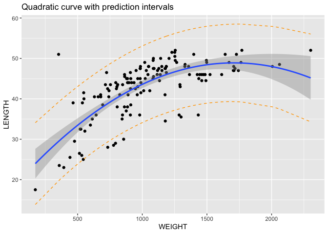

```r
# b. Quadratic curve with points added
library("ggplot2")
p <- ggplot(dmore, aes(x= WEIGHT, y = LENGTH)) +
  geom_point() +
  stat_smooth(method = lm, formula = y~x+I(x^2))
# c. lower and upper lines added
p <- p + geom_line(aes(y = lwr), color = "orange", linetype = "dashed")+
    geom_line(aes(y = upr), color = "orange", linetype = "dashed")
p + ggtitle("Quadratic curve with prediction intervals")
```

# Finally

With this brief inroduction you may now start on the lab

Lab11-extinct-birds-calc.pdf, Lab11.R, MATH4753Laboratory11.docx